# Introduction to single-cell RNA-seq analysis

## 2.2 (Bonus) Further exploration

### 2.2.1 Erythrocytes

Looking at the expression of *HBA1* and *HBA2*:

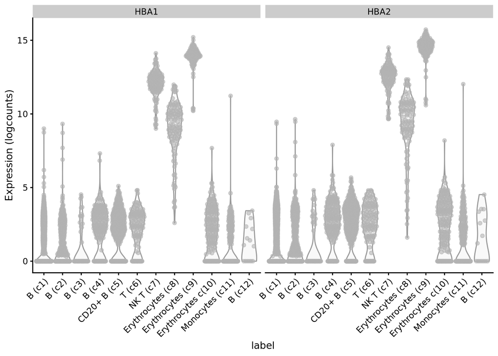

```r
plotExpression(sce, x = "label", features = c("HBA1", "HBA2")) +
  scale_x_discrete(guide = guide_axis(angle = 45))
```

You may notice that there is a lot of background expression across several cell clusters. *HBA1* and *HBA2* are common components of the **“soup” or ambient RNA** in scRNA-seq experiments involving blood cells. Hemoglobin chains, such as *HBA1* and *HBA2*, are very highly expressed in red blood cells and burst red blood cells will contribute their RNA to the medium from which the cells are loaded into the 10X Chromium machine. Some of this medium, or “soup”, containing ambient RNA is captured with each cell. There are methods available to correct for soup in your analysis such as [SoupX](https://academic.oup.com/gigascience/article/9/12/giaa151/6049831).

### 2.2.2 B Cells

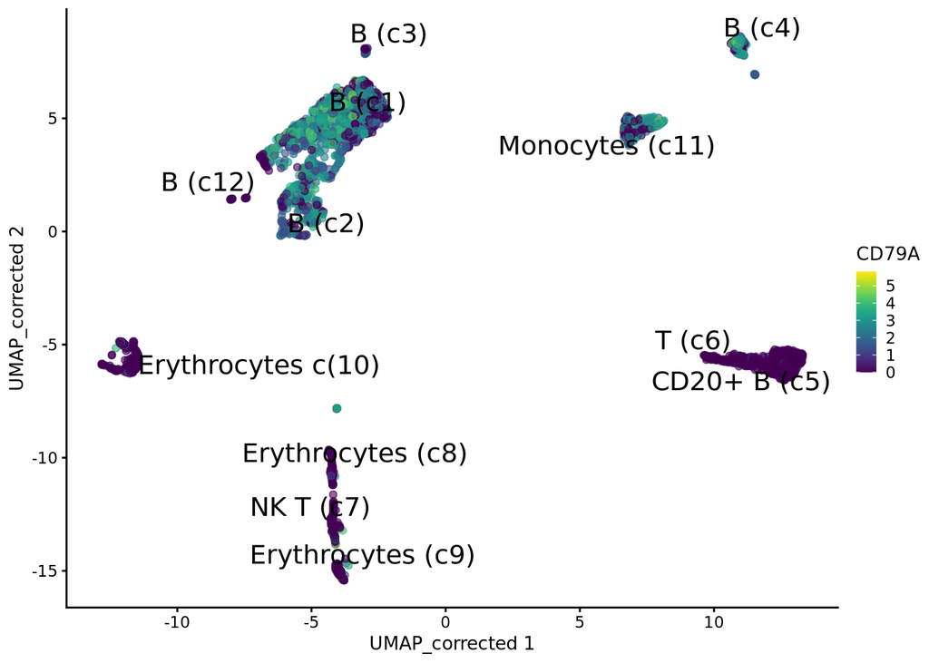

```r
plotReducedDim(sce, dimred = "UMAP_corrected",
               colour_by = "CD79A", text_by = "label")
```

We could look at our list of top markers and identify any that are unique to this cluster:

```r
setdiff(top_markers_all[[12]], unlist(top_markers_all[1:11]))
```

```
##  [1] "BCL11A"          "BARD1"           "ITM2C"           "RBM47"
##  [5] "JCHAIN"          "RUFY3"           "PLAC8"           "FHIP1A"
##  [9] "RUNX2"           "SNX9"            "COX6C"           "ENSG00000225885"
## [13] "GNAQ"            "TXN"             "IRF7"            "RPS25"
## [17] "CD4"             "C12orf75"        "SLC15A4"         "FLT3"
## [21] "ALOX5AP"         "RNASE6"          "IRF8"            "P4HB"
## [25] "MYL12B"          "PTPRS"           "LILRA4"          "APP"
## [29] "CSF2RA"          "PLP2"
```

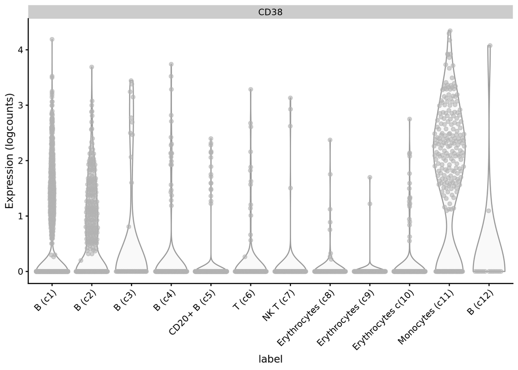

```r
plotExpression(sce, x = "label",
               features = "CD38") +
  scale_x_discrete(guide = guide_axis(angle = 45))
```

One thing to note is that this cluster only seems to contain cells from PBMMC samples:

```r
table(sce$SampleGroup, sce$label)
```

```
##
##              B (c1) B (c2) B (c3) B (c4) CD20+ B (c5) T (c6) NK T (c7)
##   ETV6-RUNX1   1188    284     49     71          218     38        56
##   PBMMC         106    132      9    138          296    103        62
##
##              Erythrocytes (c8) Erythrocytes (c9) Erythrocytes c(10)
##   ETV6-RUNX1                26                65                  5
##   PBMMC                     90                77                209
##
##              Monocytes (c11) B (c12)
##   ETV6-RUNX1               0       0
##   PBMMC                  263      15
```

Therefore, it suggests there are absent from our cancer blood samples.

The difficulty in annotating cluster 12 exemplifies the **limitation of manual cell annotation**, which can become quite laborious and limited in its ability to classify cells.

Also, we should keep in mind that perhaps our clustering wasn’t ideal, there may have been technical issues during normalisation and dataset integration, which we should investigate (e.g. by producing UMAP and clustering from different normalisation methods).